# Analisys 3: ASD and Migraine Unexplored Association

Jânice Roberta de Paula

2025-12-29

## Introduction

In this article, the author reviews the work of three authors on the increased risk of migraine in individuals within the Autism Spectrum Disorder (ASD). The authors reviewed are: Underwood et al., 2019; Victorio, 2014; and Sullivan et al., 2014.The article begins by discussing the criteria for the diagnosis of ASD according to the DSM-5, followed by the diagnostic criteria for migraine (with and without aura) based on the ICHD-3.

## Objectives

This narrative review evaluates the evidence from the scientific literature on the co-occurrence of ASD and migraine, with the aim of shedding light on this relatively underexplored association. The central objective of this review is to better delineate the main state-of-the-art research findings on the comorbidity between ASD and migraine, suggesting possible related pathophysiological mechanisms and assessing whether patients with ASD are vulnerable to underrecognition and undertreatment of migraine.

## Methods

A review of several articles published over the years was conducted by performing a search using the following syntax: “autism” (Title/Abstract) OR “Asperger” (Title/Abstract) OR “pervasive developmental disorders” (Title/Abstract) AND “migraine” (Title/Abstract). References were identified through electronic database searches in CENTRAL, Ovid MEDLINE, Embase, and PsycINFO.

## Results

Autism and migraine share common pathophysiological alterations, including dysregulation of neurotransmission—particularly of the serotonergic system; altered immune responses causing neurogenic neuroinflammation; abnormal findings, especially in cortical minicolumn organization and in a dysfunctional gut–brain axis and shared susceptibility genes.

**Table 1 - Migraine Comorbidity in Autism(ASD)**

Studies of Migraine Comorbidity in Autism (ASD)

| Study | ASD Sample | Migraine Rate (%) | Other Findings |
| --- | --- | --- | --- |
| Underwood et al., 2019 [21] | 105 adults (76 healthy controls) without intellectual disability | 42.7 | High rate (89.5%) of psychiatric comorbidities (depression 62.9%; anxiety 55.2%) |
| Victorio, 2014 [22] | 18 children | 61.0 | 44% without aura; 5.6% with aura and 11% both types |
| Sullivan et al., 2014 [23] | 81 children | 28.4 | More generalized anxiety and sensory hyperreactivity |

**Plot Table - Migraine Comorbidity in Autism(ASD)**

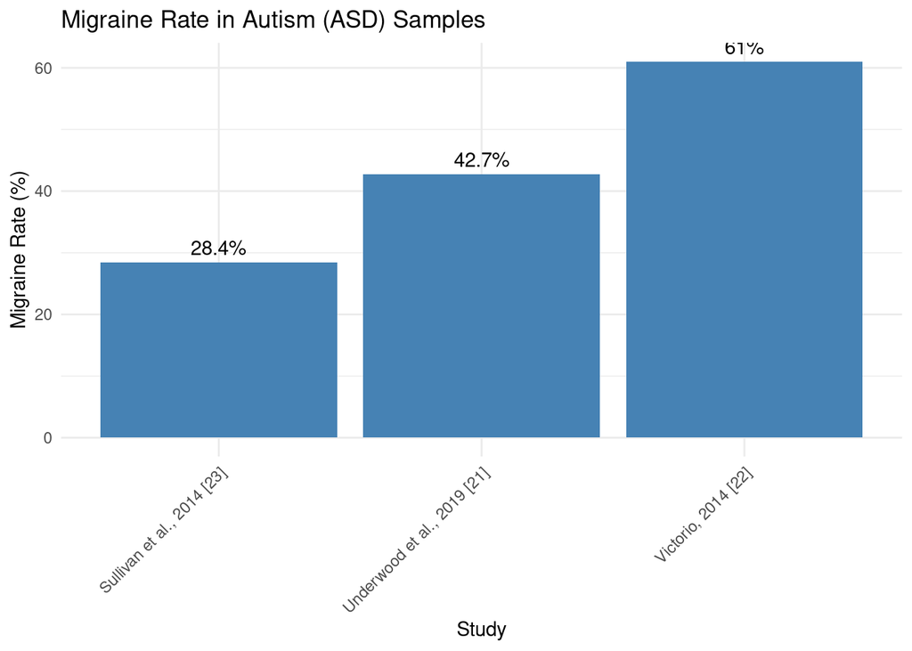

## Conclusion

Although autism and migraine are two common neurological conditions, only a few studies have investigated their comorbidity. These studies, despite involving small samples of individuals with autism, indicate a high rate of migraine symptomatology. Individuals with autism frequently exhibit altered pain sensitivity, which may distort their perception of headaches. In addition, the social dimension of pain may be impaired in people with autism, with unpredictable consequences for pain reporting. Regarding the comorbidity between autism and migraine, it is clear that further epidemiological studies are needed to account for the true scale of this relatively unexplored association.